# Multiple Linear Regression on fish Dataset

Utkarsh

2022-09-24

## Introduction

A fish market is a marketplace for selling fish and fish products. It can be dedicated to wholesale trade between fishermen and fish merchants, or to the sale of seafood to individual consumers, or to both. Retail fish markets, a type of wet market, often sell street food as well.

## 1. Aim of the project

Our Aim is to Exploratory Data analysis on the 7 species of fish data for market sale and explain the linear dependence of Weight of fish on the different variables on the basis of Linear Regression.

### Meanings of the Columns:

- Species: Species name of fish
- Weight: Weight of fish in gram
- Length1: Vertical length in cm
- Length2: Diagonal length in cm
- Length3: Cross length in cm
- Height: Height in cm
- Width: Diagonal width in cm

Our dependent variable is ‘Weight’. Independent variables are ‘species’, different lengths, ‘height’ and ‘width’.

I will use independent variables (measurements of the fish) to estimate dependent variable (weight of the fish).

### Steps to follow:

- Download and preliminary analysis of data
- Linear Regression
- Multiple Regression
- Verifying Assumptions of Multiple Linear Regression

## 2. Importing Libraries

The following Libraries would be used

```r
library(dplyr)
```

```r
library(ggplot2)
library(GGally)
library(car)
library(MLmetrics)
library(lmtest)
```

## 3. Importing and cleaning Dataset

```r
# Loading the dataset File
library(readr)
fish_data<- read.csv("C:/Users/utkar/OneDrive/Desktop/22N0063 R/Fish.csv")
View(fish_data)
head(fish_data)
```

```
##   Species Weight Length1 Length2 Length3  Height  Width
## 1   Bream    242    23.2    25.4    30.0 11.5200 4.0200
## 2   Bream    290    24.0    26.3    31.2 12.4800 4.3056
## 3   Bream    340    23.9    26.5    31.1 12.3778 4.6961
## 4   Bream    363    26.3    29.0    33.5 12.7300 4.4555
## 5   Bream    430    26.5    29.0    34.0 12.4440 5.1340
## 6   Bream    450    26.8    29.7    34.7 13.6024 4.9274
```

```r
# Removing the Outliers
fish_data=fish_data[-c(142,143,144,145),]
View(fish_data)
nrow(fish_data)
```

```
## [1] 155
```

### Duplicate and Missing values

```r
anyDuplicated(fish_data)
```

```
## [1] 0
```

```r
sum(is.na(fish_data))
```

```
## [1] 0
```

```r
# Since our data doesn't contain any duplicate or na values we are done.
```

## 4. Exploring the dataset

### 4.1 Summary of the dataset

```r
summary(fish_data)
```

```
##    Species              Weight          Length1         Length2
##  Length:155         Min.   :   0.0   Min.   : 7.50   Min.   : 8.4
##  Class :character   1st Qu.: 120.0   1st Qu.:19.00   1st Qu.:21.0
##  Mode  :character   Median : 270.0   Median :25.00   Median :26.5
##                     Mean   : 369.6   Mean   :25.49   Mean   :27.6
##                     3rd Qu.: 605.0   3rd Qu.:32.00   3rd Qu.:35.0
##                     Max.   :1100.0   Max.   :48.30   Max.   :51.7
##     Length3          Height           Width
##  Min.   : 8.80   Min.   : 1.728   Min.   :1.048
##  1st Qu.:22.95   1st Qu.: 5.927   1st Qu.:3.364
##  Median :29.20   Median : 7.616   Median :4.239
##  Mean   :30.38   Mean   : 8.940   Mean   :4.359
##  3rd Qu.:39.35   3rd Qu.:12.379   3rd Qu.:5.373
##  Max.   :55.10   Max.   :18.957   Max.   :8.142
```

## Barplot of the discrete Variable

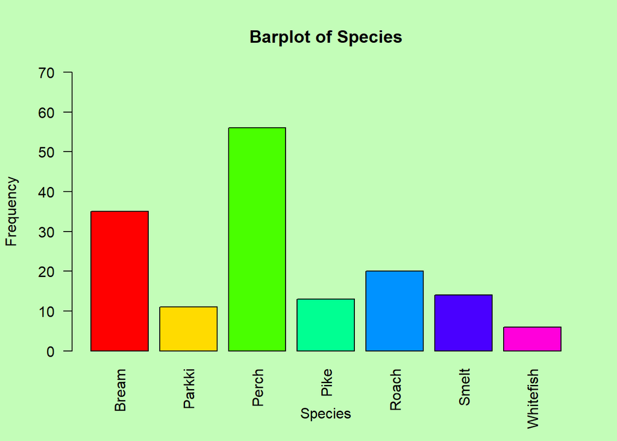

```r
Species=fish_data$Species
par(bg="#C3FDB8")
T=table(Species)
barplot(T,xlab="Species",ylab="Frequency",main = "Barplot of Species",col=rainbow(7),ylim=c(0,70),las=2)
```

## Histogram and barplot of the Continuous Variable

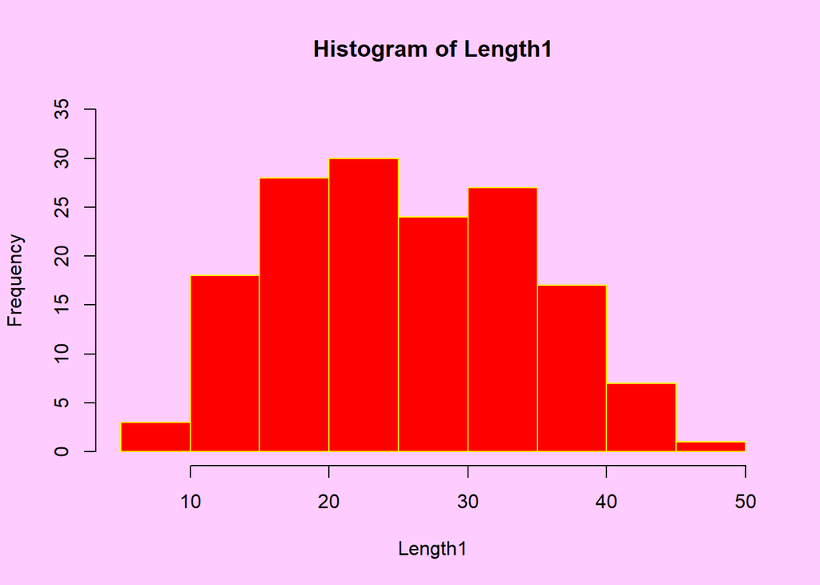

```r
par(bg="#FFCCFF")
Length1=fish_data$Length1
hist(Length1,col="red",border="yellow",ylim=c(0,35))
```

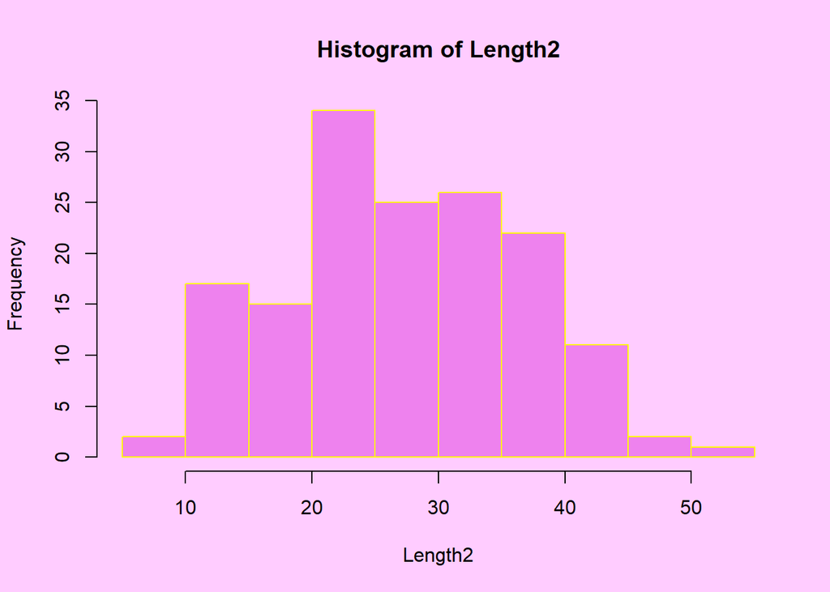

```r
Length2=fish_data$Length2
hist(Length2,col="violet",border="yellow")
```

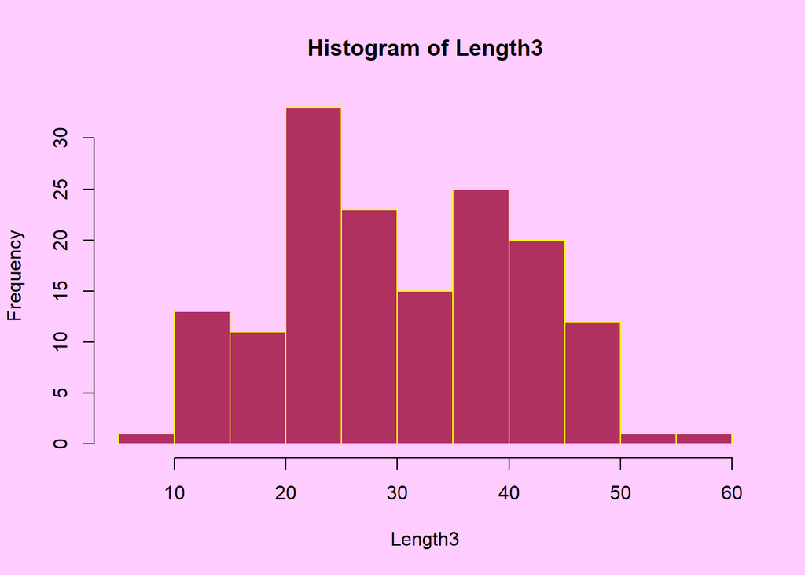

```r
Length3=fish_data$Length3
hist(Length3,col="maroon",border="yellow")
```

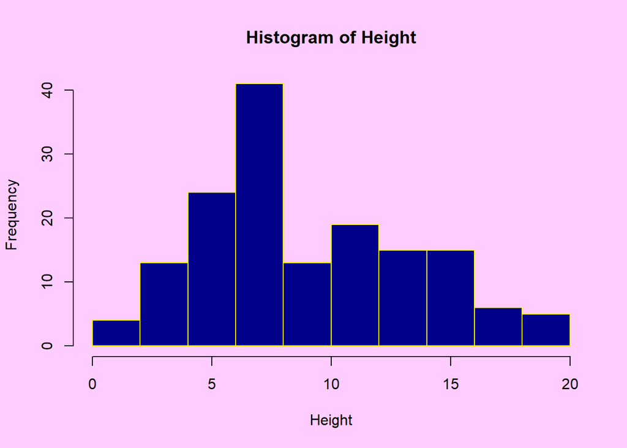

```r
Height=fish_data$Height
hist(Height,col="#00008B",border="yellow")
```

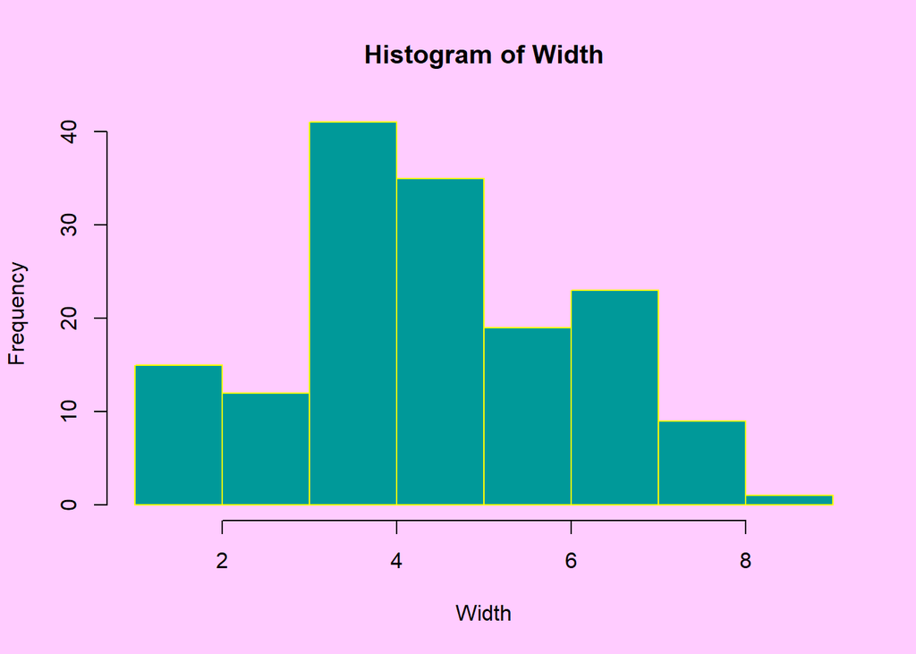

```r
Width=fish_data$Width
hist(Width,col="#009999",border="yellow")
```

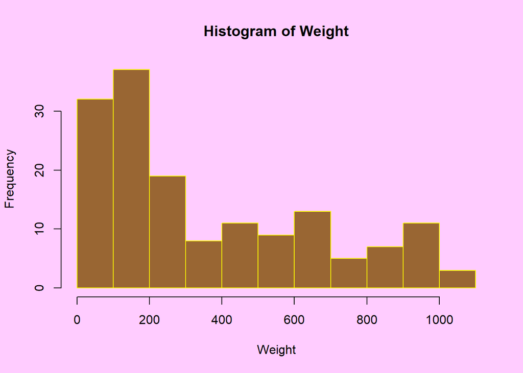

```r
Weight=fish_data$Weight
hist(Weight,col="#996633",border="yellow")
```

## Boxplot of Continuous Variable

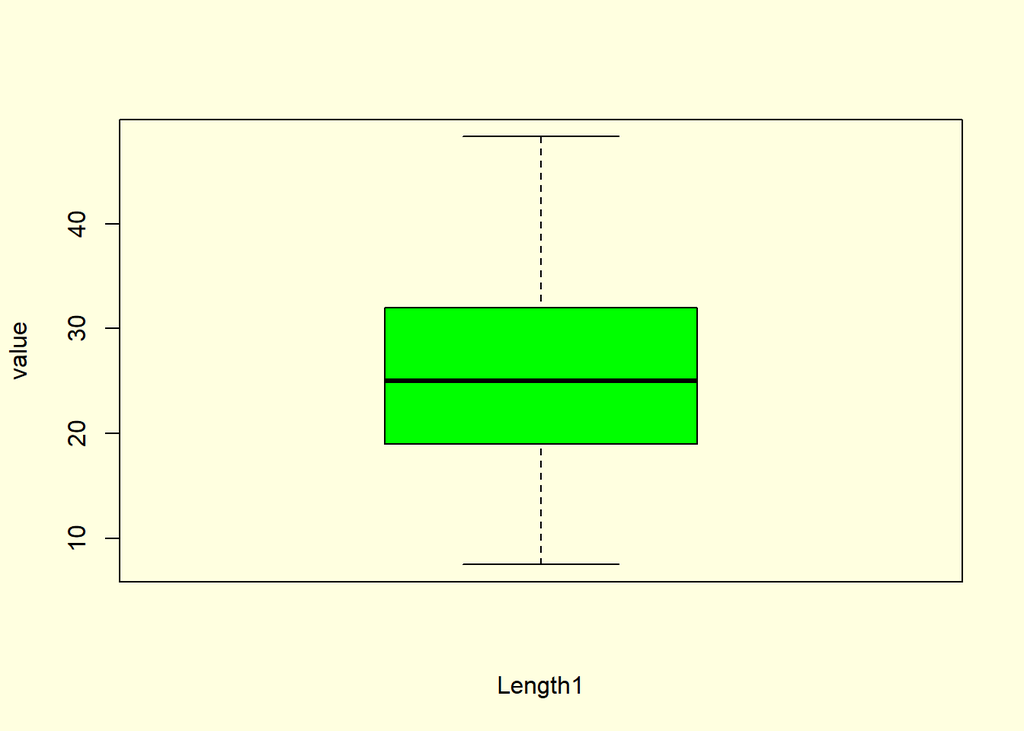

```r
par(bg="#FFFFE0")
boxplot(Length1,xlab="Length1",ylab="value",col="green")
```

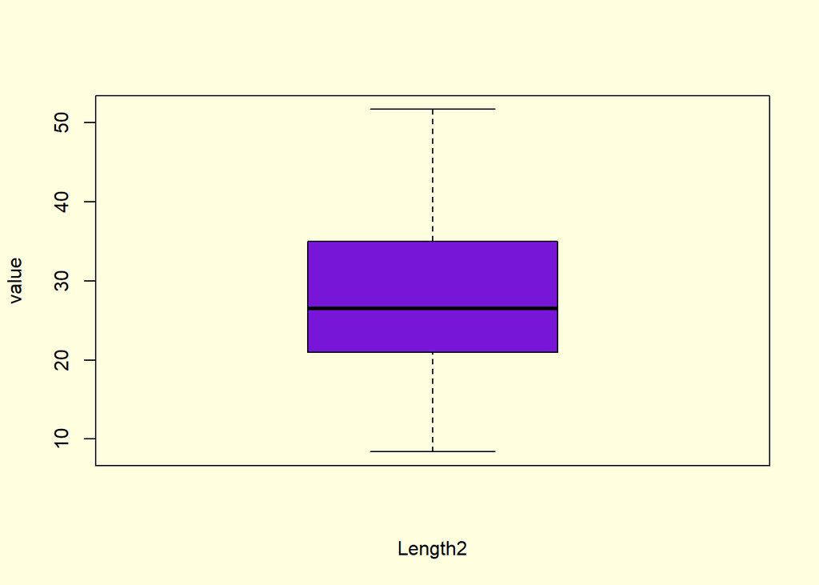

```r
boxplot(Length2,xlab="Length2",ylab="value",col="#7716D7")
```

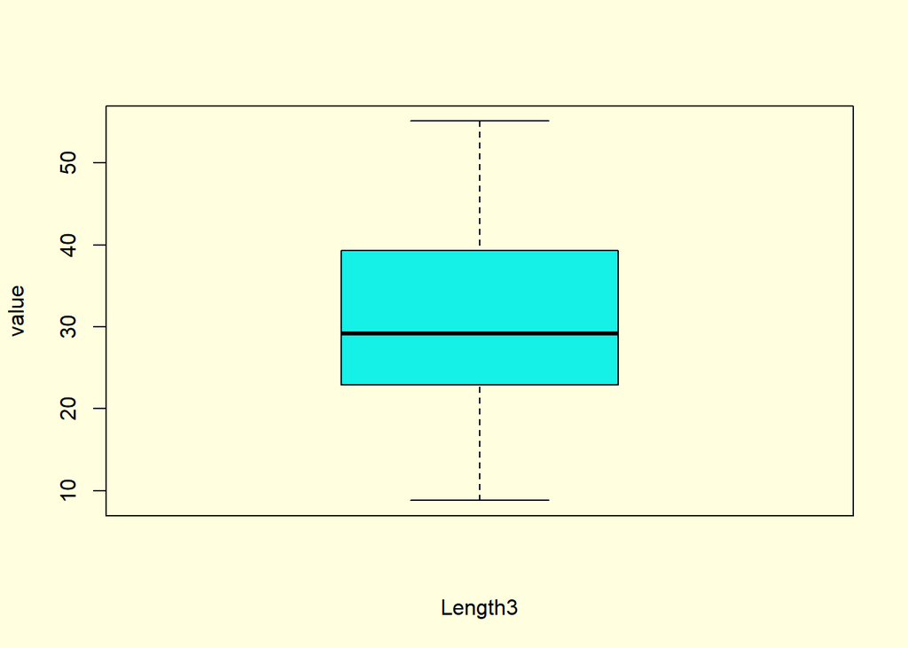

```r
boxplot(Length3,xlab="Length3",ylab="value",col="#16F1E7")
```

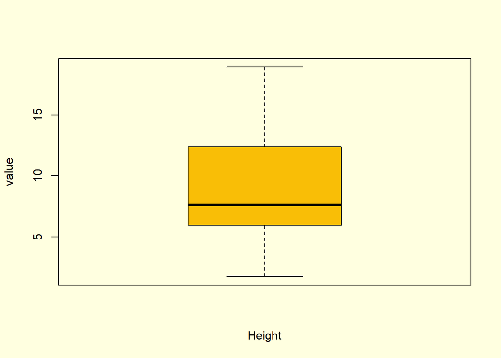

```r
boxplot(Height,xlab="Height",ylab="value",col="#F9BE06")
```

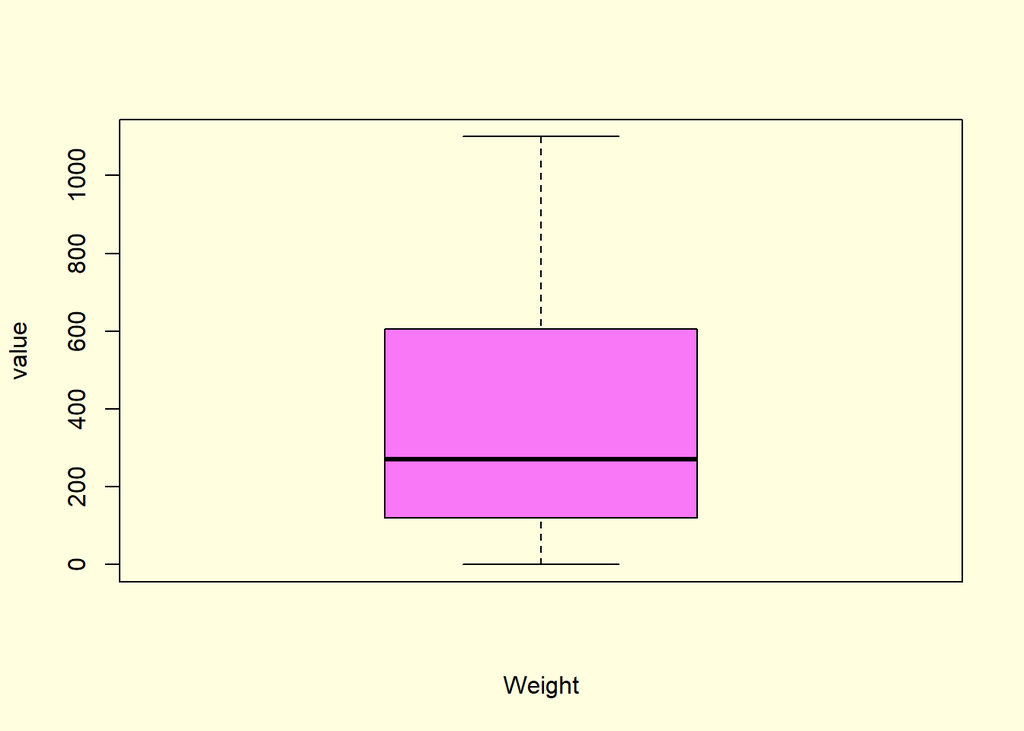

```r
boxplot(Weight,xlab="Weight",ylab="value",col="#F978F7")
```

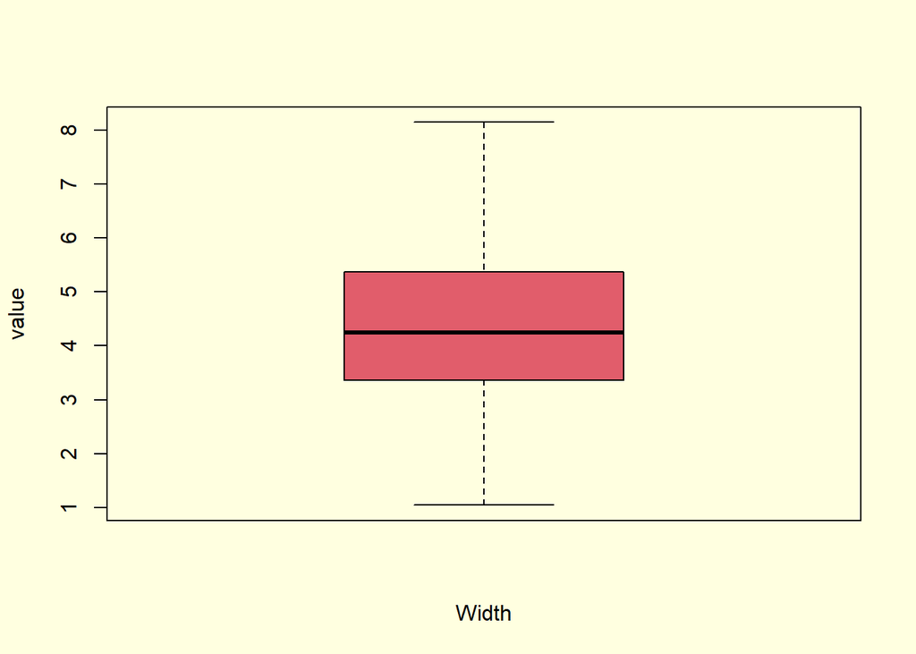

```r
boxplot(Width,xlab="Width",ylab="value",col="#E15D6B")
```

We can See from the Boxplot of the Variables there are no significant outliers in our data

## Scatter Plot

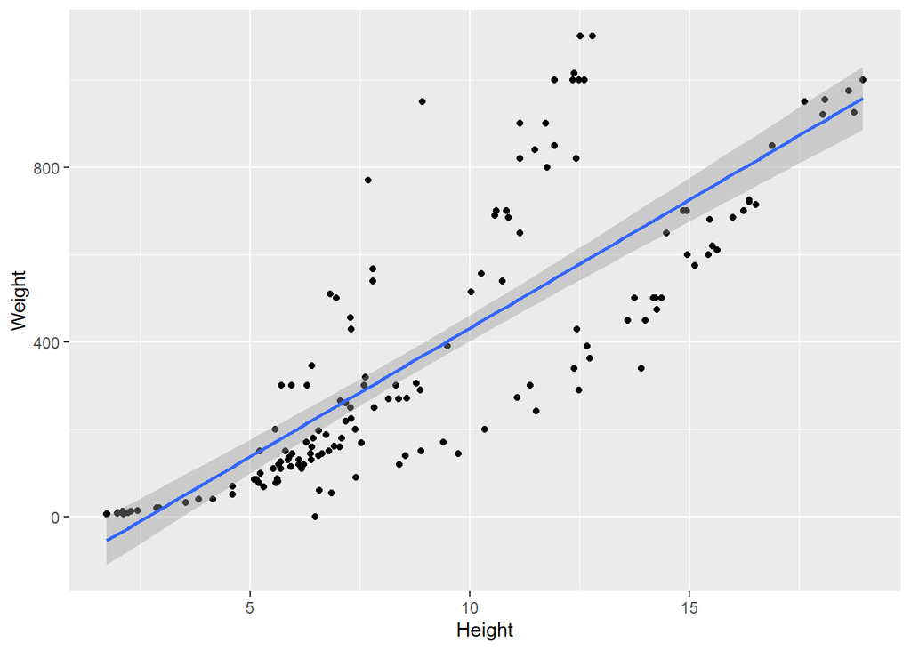

```r
ggplot(fish_data, aes(x=Height, y=Weight)) + geom_point()+geom_smooth(method = "lm")
```

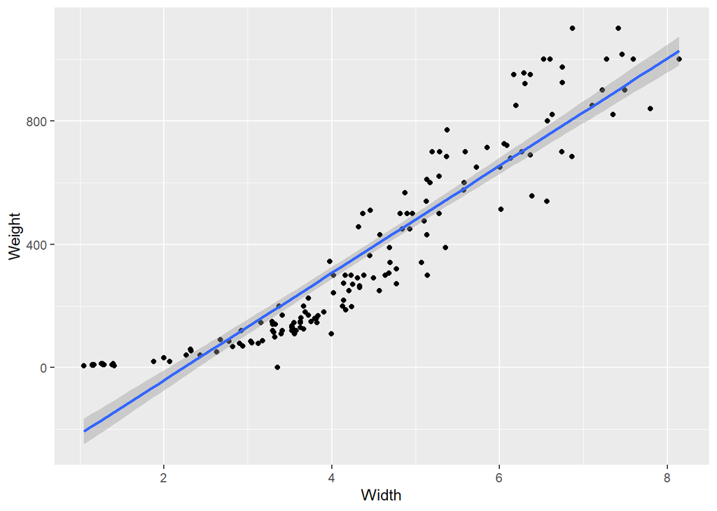

```r
ggplot(fish_data, aes(x=Width, y=Weight)) + geom_point()+geom_smooth(method = "lm")
```

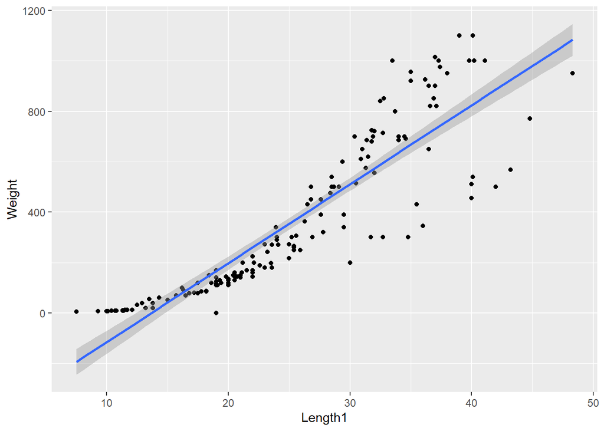

```r
ggplot(fish_data, aes(x=Length1, y=Weight)) + geom_point()+geom_smooth(method = "lm")
```

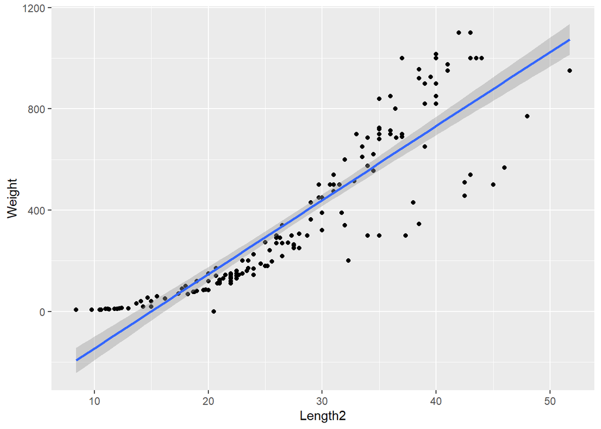

```r
ggplot(fish_data, aes(x=Length2, y=Weight)) + geom_point()+geom_smooth(method = "lm")
```

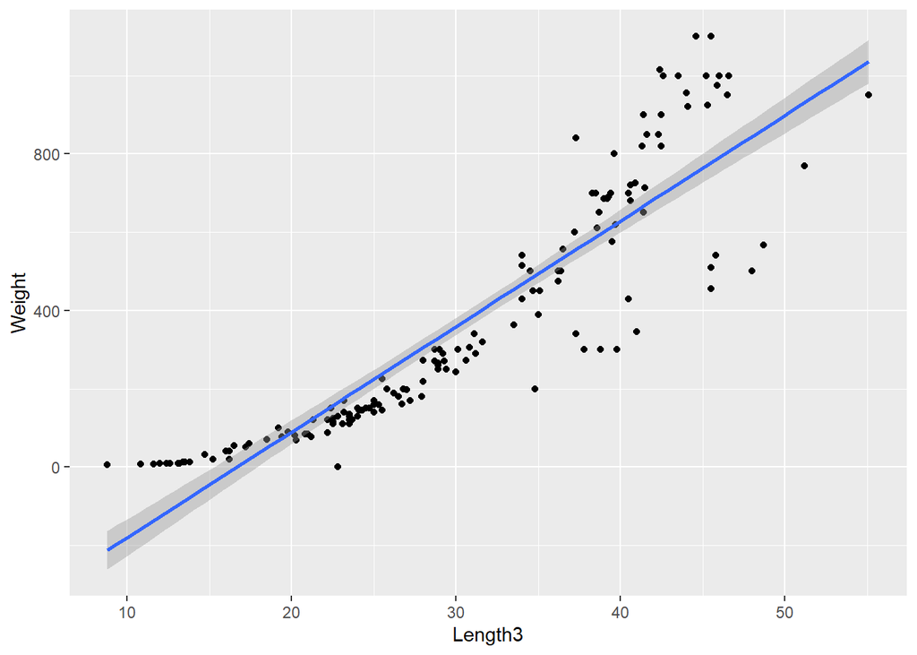

```r
ggplot(fish_data, aes(x=Length3, y=Weight)) + geom_point()+geom_smooth(method = "lm")
```

As we can see from Scatter plot all independent variables are positively related with the dependent variable (i.e. Weight).

## Checking the Correlation between each variable

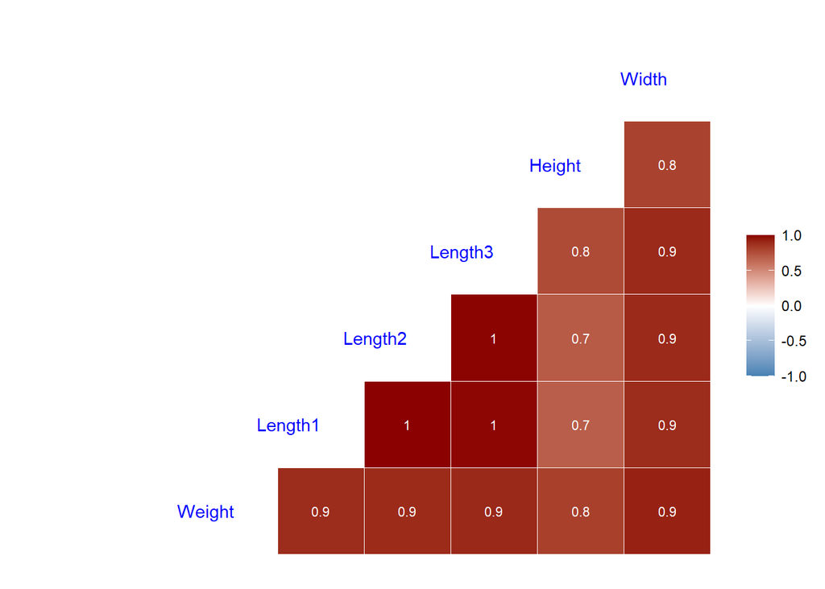

```r
par(bg="#E9C9F3")
ggcorr(fish_data %>% select(-c(Species)) ,
       label = TRUE, label_size = 2.9, hjust =1, layout.exp = 2, low = "steelblue", mid = "white", high = "darkred",label_color = "white", palette = "RdGy",col="blue")
```

We can see from correlation matrix that independent variables length1,length2,length3 are highly correlated and two of them need to be eliminated from our regression model and width is also highly correlated with all the lengths so it should also be eliminated from regression model.

## Modelling

### Test-Train Split

Dividing the data into two parts training and Testing dataset randomly.

```r
fish_reg <- fish_data %>%
  select(-Species)
set.seed(123)
samplesize <- round(0.8 * nrow(fish_reg), 0)
index <- sample(seq_len(nrow(fish_reg)), size = samplesize)
data_train <- fish_reg[index, ]
data_test <- fish_reg[-index, ]
```

## 5.Linear Regression

```r
fish_lm=lm(Weight~.,data=data_train)
summary(fish_lm)
```

```
##
## Call:
## lm(formula = Weight ~ ., data = data_train)
##
## Residuals:
##     Min      1Q  Median      3Q     Max
## -209.04  -65.08  -22.69   73.83  245.10
##
## Coefficients:
##             Estimate Std. Error t value Pr(>|t|)
## (Intercept) -401.703     28.014 -14.339  < 2e-16 ***
## Length1      121.243     37.305   3.250  0.00150 **
## Length2      -55.923     38.415  -1.456  0.14811
## Length3      -45.200     16.022  -2.821  0.00562 **
## Height        42.648      8.098   5.266 6.34e-07 ***
## Width         50.508     18.873   2.676  0.00851 **
## ---
## Signif. codes:  0 '***' 0.001 '**' 0.01 '*' 0.05 '.' 0.1 ' ' 1
##
## Residual standard error: 99.36 on 118 degrees of freedom
## Multiple R-squared:  0.9087, Adjusted R-squared:  0.9048
## F-statistic: 234.9 on 5 and 118 DF,  p-value: < 2.2e-16
```

Looking on Pr(>|t|) column we will take significance level of 0.05. It means if the value Pr(>|t|) is below 0.05, than we can asume that the variable has significant effect toward the model. The summary of fish_lm shows four variables(Length1,Length3,Height and Width) are significant towards the model

### Weight = -401.703+121.243(length1)-45.200 (Length3)+42.648(Height)+50.508(Width)

## 6.Step-Wise Regression

using Step-wise regression to eliminate the redundant variables(using backward elimination).

```r
fish_lm_step <-step(fish_lm, direction = "backward")
```

```
## Start:  AIC=1146.34
## Weight ~ Length1 + Length2 + Length3 + Height + Width
##
##           Df Sum of Sq     RSS    AIC
## <none>                 1164924 1146.3
## - Length2  1     20922 1185846 1146.5
## - Width    1     70704 1235628 1151.6
## - Length3  1     78575 1243499 1152.4
## - Length1  1    104278 1269202 1155.0
## - Height   1    273793 1438717 1170.5
```

```r
summary(fish_lm_step)
```

```
##
## Call:
## lm(formula = Weight ~ Length1 + Length2 + Length3 + Height +
##     Width, data = data_train)
##
## Residuals:
##     Min      1Q  Median      3Q     Max
## -209.04  -65.08  -22.69   73.83  245.10
##
## Coefficients:
##             Estimate Std. Error t value Pr(>|t|)
## (Intercept) -401.703     28.014 -14.339  < 2e-16 ***
## Length1      121.243     37.305   3.250  0.00150 **
## Length2      -55.923     38.415  -1.456  0.14811
## Length3      -45.200     16.022  -2.821  0.00562 **
## Height        42.648      8.098   5.266 6.34e-07 ***
## Width         50.508     18.873   2.676  0.00851 **
## ---
## Signif. codes:  0 '***' 0.001 '**' 0.01 '*' 0.05 '.' 0.1 ' ' 1
##
## Residual standard error: 99.36 on 118 degrees of freedom
## Multiple R-squared:  0.9087, Adjusted R-squared:  0.9048
## F-statistic: 234.9 on 5 and 118 DF,  p-value: < 2.2e-16
```

```r
fish_lm_step2=lm(Weight~Length1+Height,data=data_train)
summary(fish_lm_step2)
```

```
##
## Call:
## lm(formula = Weight ~ Length1 + Height, data = data_train)
##
## Residuals:
##     Min      1Q  Median      3Q     Max
## -261.62  -70.44  -30.40   74.97  318.25
##
## Coefficients:
##             Estimate Std. Error t value Pr(>|t|)
## (Intercept) -439.000     31.081 -14.124   <2e-16 ***
## Length1       22.206      1.631  13.616   <2e-16 ***
## Height        27.711      3.381   8.195    3e-13 ***
## ---
## Signif. codes:  0 '***' 0.001 '**' 0.01 '*' 0.05 '.' 0.1 ' ' 1
##
## Residual standard error: 116.2 on 121 degrees of freedom
## Multiple R-squared:  0.872,  Adjusted R-squared:  0.8699
## F-statistic: 412.1 on 2 and 121 DF,  p-value: < 2.2e-16
```

## 7. Checking the Assumptions

In Linear regression Method, there are a few assumption that need to be fulfilled. Suppose the assumptions are not satisfied, the result of the model may be inaccurate or misleading.

Assumptions to be checked

1.Linearity

2.Normality

3.Homoscedasticity

4.Multicolinearity

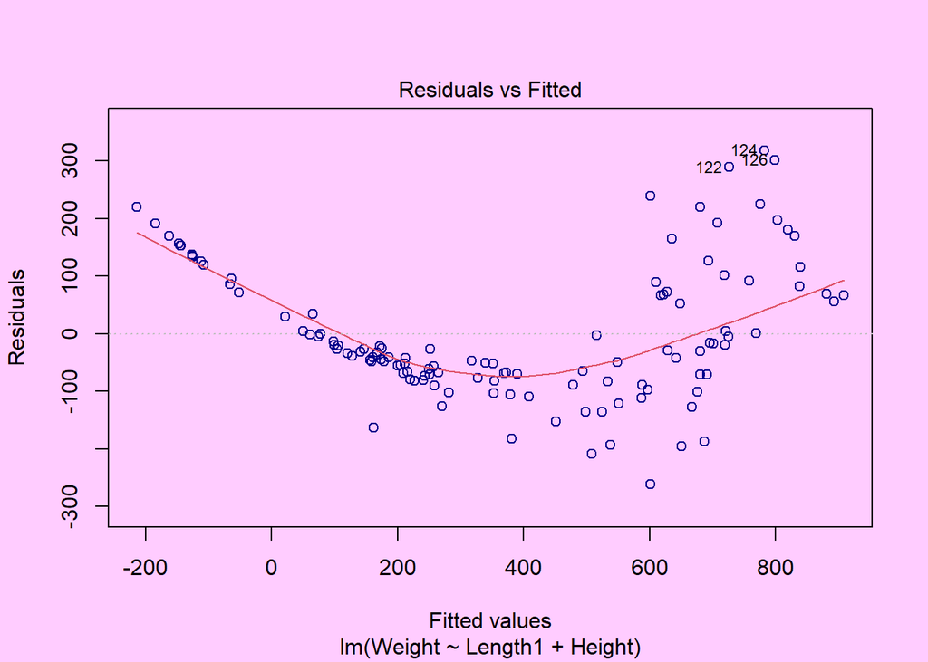

```r
par(bg="#FFCCFF")
plot(fish_lm_step2,col="#00008B",1)
```

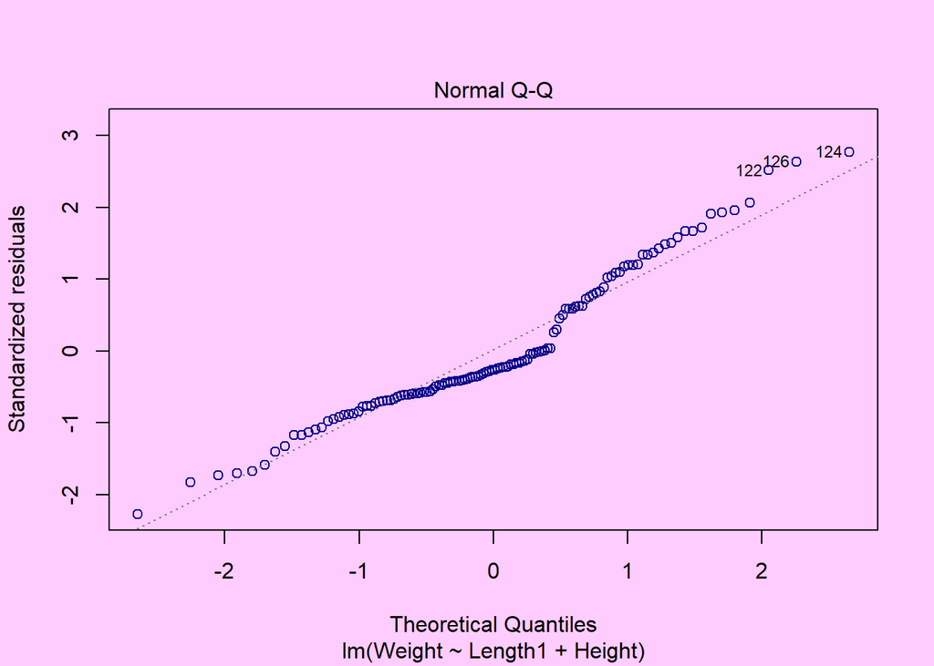

```r
# To verify Linearity assumptions Residual vs Fitted should be linear but we are getting Quadratic curve so linearity assumption is violated.
plot(fish_lm_step2,col="#00008B",2)
```

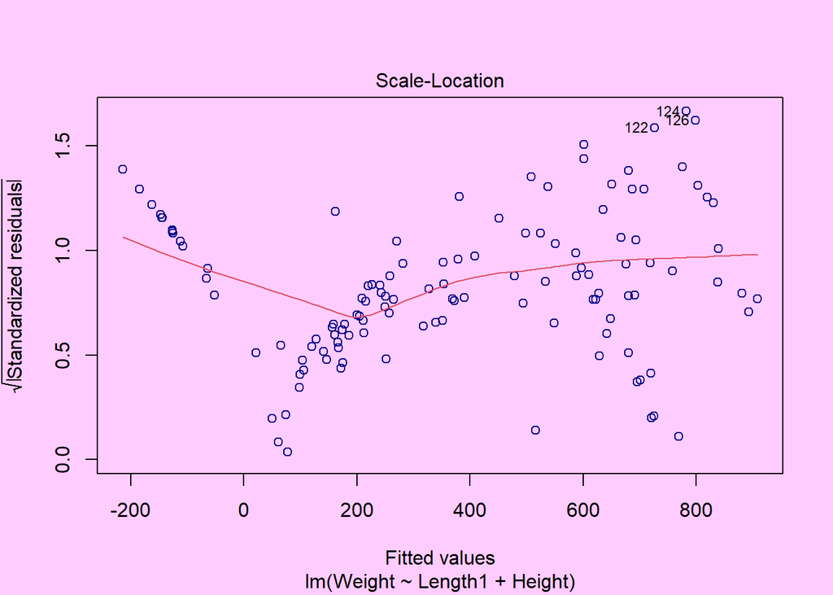

```r
# Normal Q-Q plot is used to examine whether the residuals are normally distributed. the residual do not exactly follow the dashed line so the normality assumption is violated.
plot(fish_lm_step2,col="#00008B",3)
```

```r
# Used to check the homogeneity of variance of the residuals (homoscedasticity). Horizontal line with equally spread points is a good indication of homoscedasticity. Residuals are not uniformly distributed along predictors so it violates Homoscedasticity.
vif(fish_lm_step2)
```

```
##  Length1   Height
## 2.007122 2.007122
```

```r
# Multicollinearity is the occurrence of high intercorrelations among two or more independent variables in a multiple regression model. To check the multicollinearity, we can measure the variance inflation factor (VIF). There’s no multicollinearity when VIF<10 so our model doesn't have multicollinearity.
```

## 8.Improved Model

```r
fish_new <- fish_data  %>%
  mutate_if(~is.numeric(.), ~sqrt(.)) %>%
  select(Weight,Length1, Height)
set.seed(123)
data_train2 <- fish_new[index, ]
data_test2 <- fish_new[-index, ]
```

## 9.Regression on Improved Model

```r
fish_lm_new <- lm(Weight ~ Length1+Height, data = data_train2)
summary(fish_lm_new)
```

```
##
## Call:
## lm(formula = Weight ~ Length1 + Height, data = data_train2)
##
## Residuals:
##      Min       1Q   Median       3Q      Max
## -11.9086  -1.1708  -0.4555   1.6839   5.3606
##
## Coefficients:
##             Estimate Std. Error t value Pr(>|t|)
## (Intercept) -26.3095     1.1453 -22.971   <2e-16 ***
## Length1       6.2247     0.3603  17.277   <2e-16 ***
## Height        4.3564     0.4399   9.903   <2e-16 ***
## ---
## Signif. codes:  0 '***' 0.001 '**' 0.01 '*' 0.05 '.' 0.1 ' ' 1
##
## Residual standard error: 2.333 on 121 degrees of freedom
## Multiple R-squared:  0.9332, Adjusted R-squared:  0.9321
## F-statistic: 844.7 on 2 and 121 DF,  p-value: < 2.2e-16
```

## 10. Verifying Assumptions of New Model

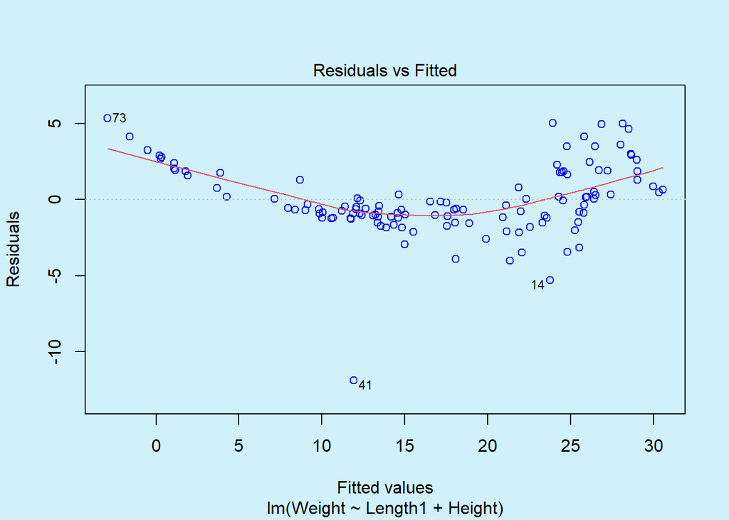

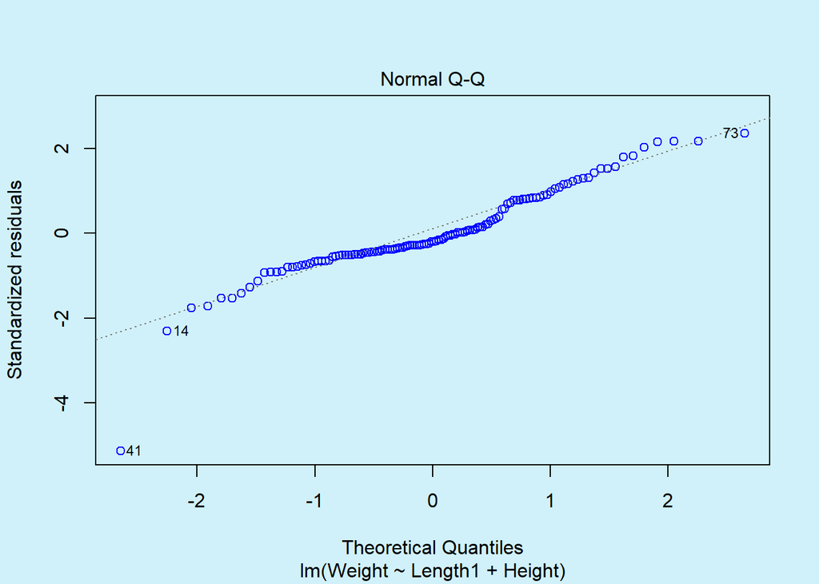

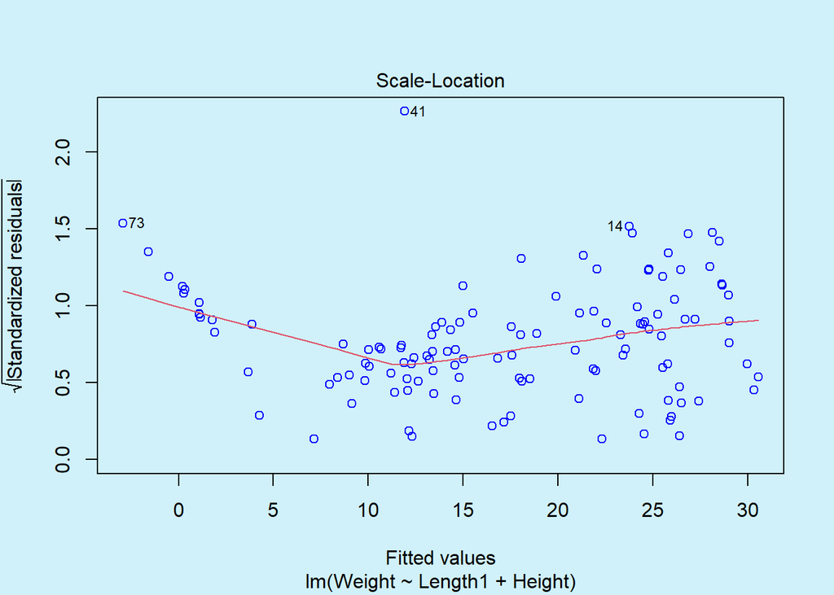

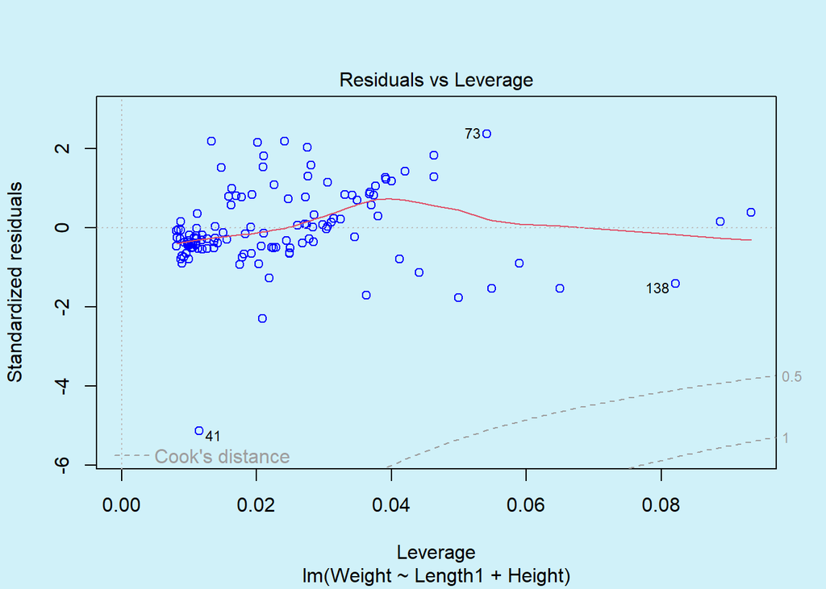

```r
par(bg="#D0F1F9")
plot(fish_lm_new,col="blue")
```

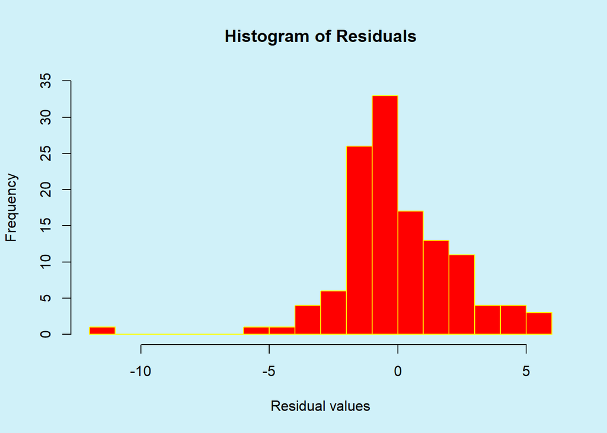

```r
hist(fish_lm_new$residuals,breaks=20,main="Histogram of Residuals",col="red",ylim=c(0,35),border = "yellow",xlab="Residual values")
```

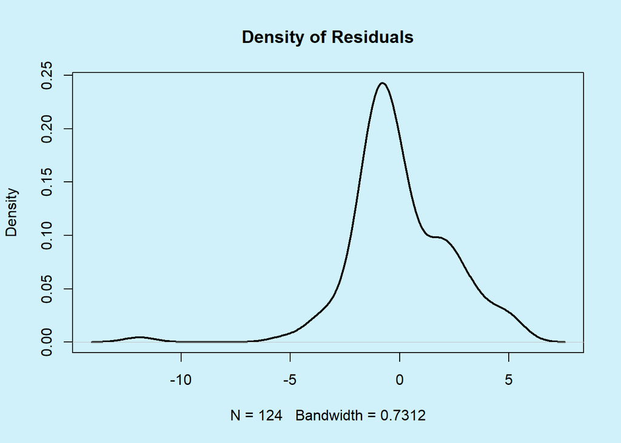

```r
plot(density(fish_lm_new$residuals),main="Density of Residuals",lwd=2)
```

```r
vif(fish_lm_new)
```

```
##  Length1   Height
## 2.547134 2.547134
```

## 11. Prediction on the basis of New Model

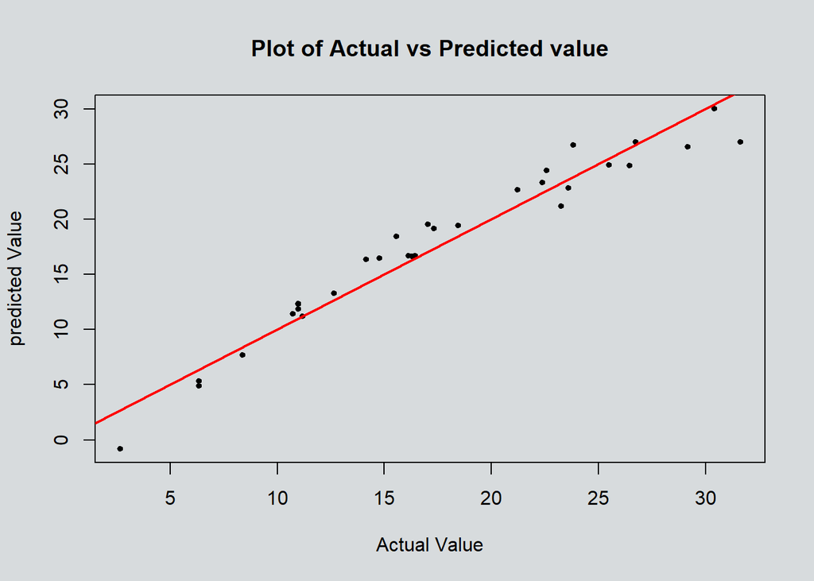

```r
lm_pred2 <- predict(fish_lm_new, newdata = data_test2 %>% select(-Weight))
par(bg="#D7DBDD")
plot(data_test2$Weight,lm_pred2,xlab="Actual Value",ylab="predicted Value",main = "Plot of Actual vs Predicted value",cex=0.6,pch=19)
abline(a=0, b=1,col="red",lwd=2)
```

As we can see from the above scatter plot almost all of the predicted value lies close to the actual value we can conform the same from the red line as most of the value lies in the vicinity of the y=x line.